# Phase2

### 10

we saw this in previous parts :

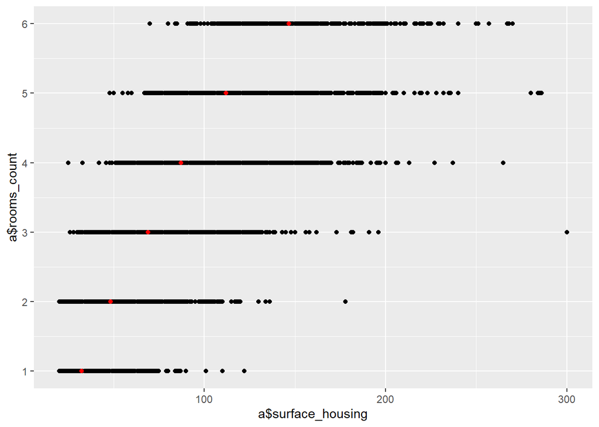

```r
r1 = (a[c("rooms_count")]==1)
r2 = (a[c("rooms_count")]==2)
r3 = (a[c("rooms_count")]==3)
r4 = (a[c("rooms_count")]==4)
r5 = (a[c("rooms_count")]==5)
r6 = (a[c("rooms_count")]==6)

ggplot() + geom_point(mapping = aes(a$surface_housing , a$rooms_count))+
    scale_y_continuous(breaks = c(0,1,2,3,4,5,6)) +
  geom_point(mapping = aes(mean(a$surface_housing[r1]) , 1) , color="red")+
  geom_point(mapping = aes(mean(a$surface_housing[r2]) , 2) , color="red")+
  geom_point(mapping = aes(mean(a$surface_housing[r3]) , 3) , color="red")+
  geom_point(mapping = aes(mean(a$surface_housing[r4]) , 4) , color="red")+
  geom_point(mapping = aes(mean(a$surface_housing[r5]) , 5) , color="red")+
  geom_point(mapping = aes(mean(a$surface_housing[r6]) , 6) , color="red")
```

let us rotate this :

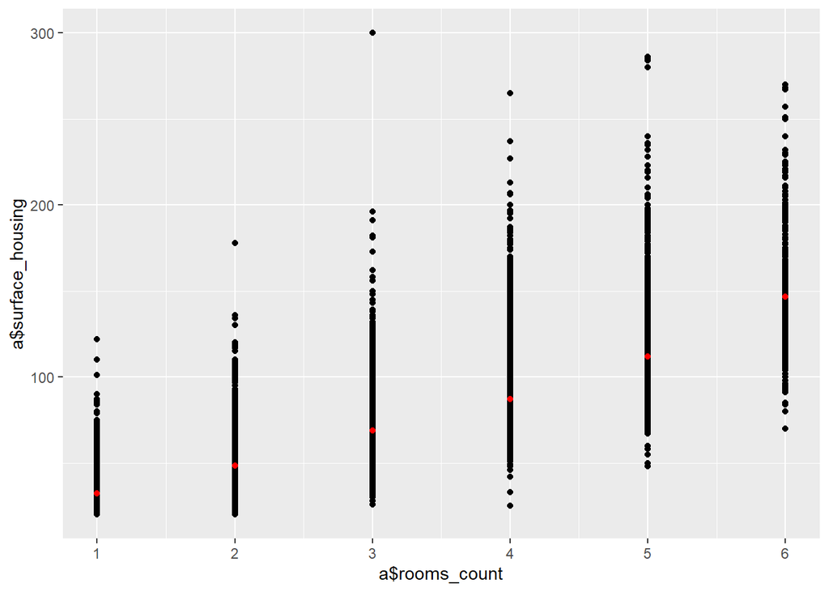

```r
ggplot() + geom_point(mapping = aes(a$rooms_count , a$surface_housing))+
    scale_x_continuous(breaks = c(0,1,2,3,4,5,6)) +
  geom_point(mapping = aes(1, mean( a$surface_housing[r1]) ) , color="red")+
  geom_point(mapping = aes(2,mean( a$surface_housing[r2]) ) , color="red")+
  geom_point(mapping = aes(3,mean( a$surface_housing[r3]) ) , color="red")+
  geom_point(mapping = aes(4,mean( a$surface_housing[r4]) ) , color="red")+
  geom_point(mapping = aes(5, mean(a$surface_housing[r5]) ) , color="red")+
  geom_point(mapping = aes(6,mean( a$surface_housing[r6]) ) , color="red")
```

if we run regression on this set :

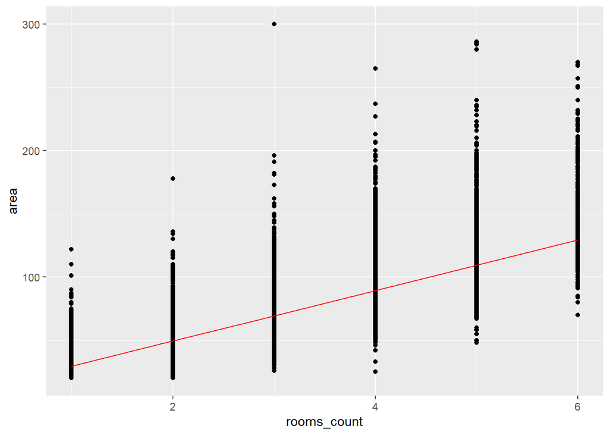

```r
fit2 = lm(surface_housing ~ rooms_count , data = a)
b0 = coef(fit2)[1]
b1 = coef(fit2)[2]


res = b0 +  b1 * a$rooms_count
new_df2 = data.frame(a$rooms_count , res , stringsAsFactors = F)
colnames(new_df2) = c("rooms_count" , "area")

ggplot(data = new_df2, aes(x = rooms_count, y = area))+geom_point(mapping = aes(a$rooms_count , a$surface_housing))+ geom_line(color='red',data = new_df2, aes(x=rooms_count, y=area))
```

so our assumption about increasing surface_housing when number of rooms increases is proved by regression.(slope of the line is posstive.)

### 11

we saw this in previous parts(I rotate it):

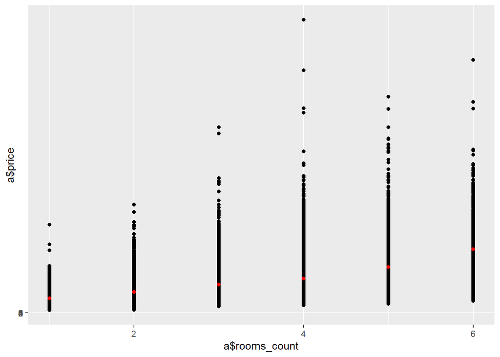

```r
r1 = (a[c("rooms_count")]==1)
r2 = (a[c("rooms_count")]==2)
r3 = (a[c("rooms_count")]==3)
r4 = (a[c("rooms_count")]==4)
r5 = (a[c("rooms_count")]==5)
r6 = (a[c("rooms_count")]==6)


ggplot() + geom_point(mapping = aes(a$rooms_count , a$price)) +
  scale_y_continuous(breaks = c(0,1,2,3,4,5,6))+
  geom_point(mapping = aes(1,mean(a$price[r1])) , color="red")+
  geom_point(mapping = aes(2,mean(a$price[r2]) ) , color="red")+
  geom_point(mapping = aes(3,mean(a$price[r3]) ) , color="red")+
  geom_point(mapping = aes(4,mean(a$price[r4]) ) , color="red")+
  geom_point(mapping = aes(5,mean(a$price[r5]) ) , color="red")+
  geom_point(mapping = aes(6,mean(a$price[r6]) ) , color="red")
```

if we run regression on this set :

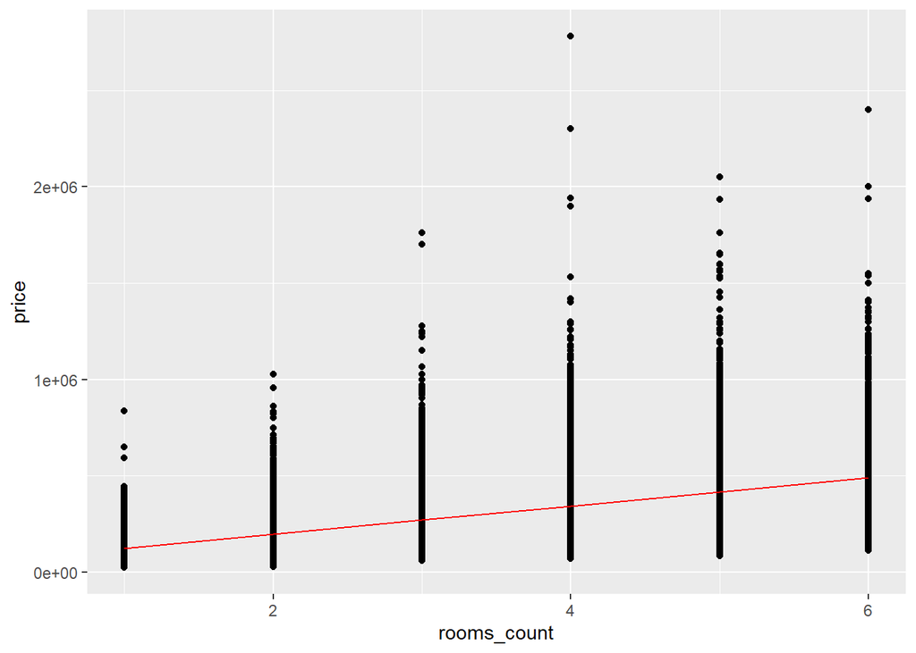

```r
fit2 = lm(price ~ rooms_count , data = a)
b0 = coef(fit2)[1]
b1 = coef(fit2)[2]


res = b0 +  b1 * a$rooms_count
new_df2 = data.frame(a$rooms_count , res , stringsAsFactors = F)
colnames(new_df2) = c("rooms_count" , "price")

ggplot(data = new_df2, aes(x = rooms_count, y = price))+geom_point(mapping = aes(a$rooms_count , a$price))+ geom_line(color='red',data = new_df2, aes(x=rooms_count, y=price))
```

again, our assumption that price and rooms_count have positive correlation is proved by regression.

### 12

for houses with non-zero terrain, let’s see if the area of the terrain affects the price(e.g price of the house increase if it has larger terrain):

first we select houses with non-zero terrain:

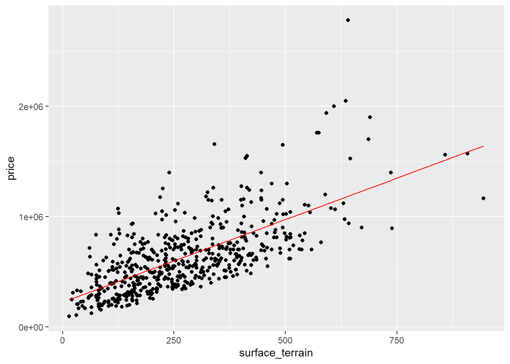

```r
rt = a[a$surface_terrain >0 , ]

fit2 = lm(price ~ surface_terrain , data = rt)
b0 = coef(fit2)[1]
b1 = coef(fit2)[2]


res = b0 +  b1 * rt$surface_terrain
new_df2 = data.frame(rt$surface_terrain , res , stringsAsFactors = F)
colnames(new_df2) = c("surface_terrain" , "price")

ggplot(data = new_df2, aes(x = surface_terrain, y = price))+geom_point(mapping = aes(rt$surface_terrain , rt$price))+ geom_line(color='red',data = new_df2, aes(x=surface_terrain, y=price))
```

```r
cor(rt$price , rt$surface_housing)
```

```
## [1] 0.5203034
```

### 13

in PART I , we plotted a figure of changing “area_price_ratio” over time for each district.

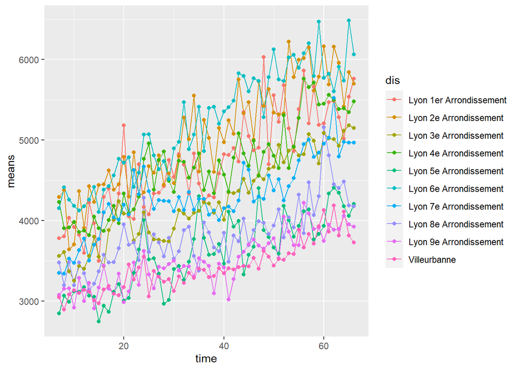

now we choose one of the districts, then plot its points :

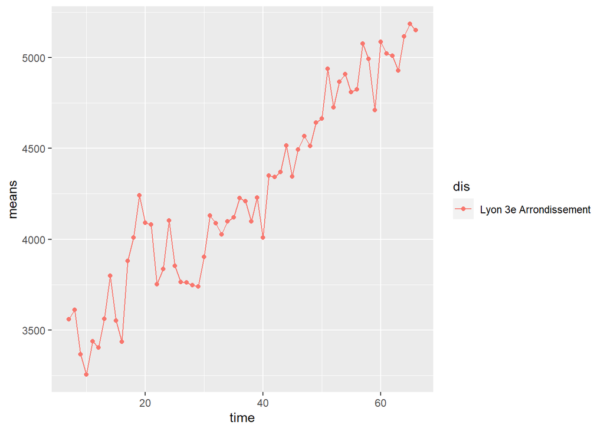

```r
spec_district = "Lyon 3e Arrondissement"
nbv3 = nbv2[nbv2$dis == spec_district , ]


ggplot(nbv3, aes(x=time, y=means, group=dis)) +
  geom_line(aes(color=dis))+
  geom_point(aes(color=dis))
```

again, let’s run regression on these points :)

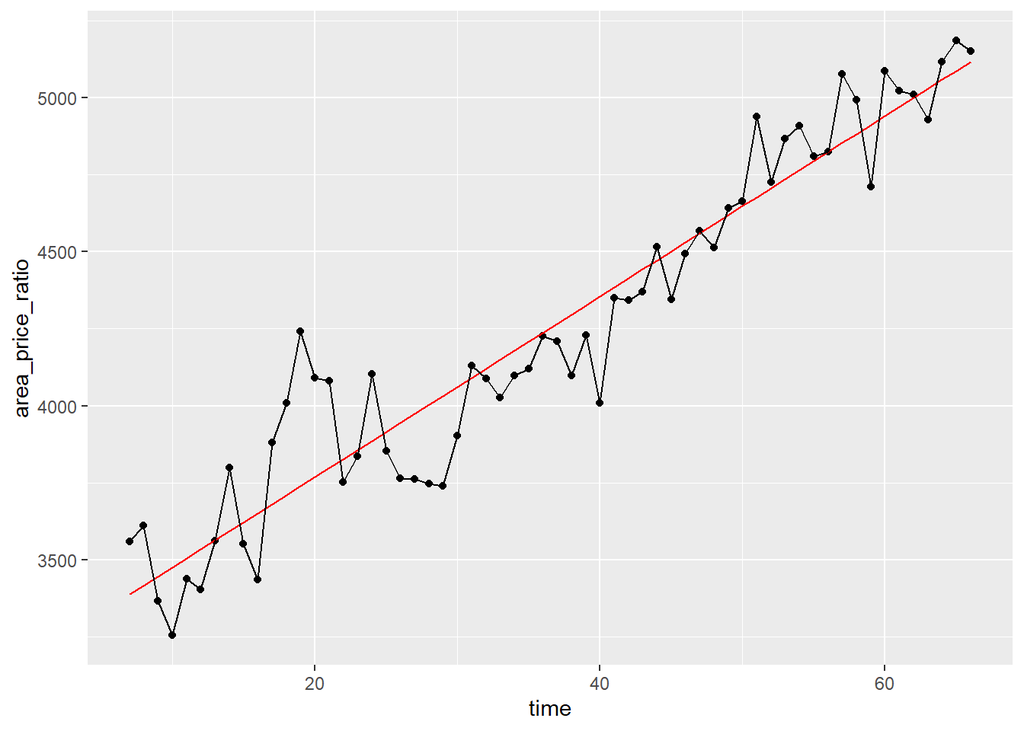

```r
fit4 = lm(means ~ time , data=nbv3)

b0 = coef(fit4)[1]
b1 = coef(fit4)[2]


res = b0 +  b1 * nbv3$time
new_df2 = data.frame(nbv3$time , res , stringsAsFactors = F)
colnames(new_df2) = c("time" , "area_price_ratio")

ggplot(data = new_df2, aes(x = time, y = area_price_ratio)) +geom_point(mapping = aes(nbv3$time , nbv3$means)) + geom_line(color='red',data = new_df2, aes(x=time, y=area_price_ratio)) +geom_line(mapping = aes(nbv3$time , nbv3$means))
```

```r
# ggplot(data = new_df2, aes(x = time, y = price))+geom_point(mapping = aes(nbv3$time , nbv3$means))+ geom_line(color='red',data = new_df2, aes(x=surface_terrain, y=price))
```

```r
summary(fit4)
```

```
##
## Call:
## lm(formula = means ~ time, data = nbv3)
##
## Residuals:
##     Min      1Q  Median      3Q     Max
## -344.72  -90.54  -16.47  100.68  500.94
##
## Coefficients:
##             Estimate Std. Error t value Pr(>|t|)
## (Intercept) 3182.268     50.294   63.27   <2e-16 ***
## time          29.314      1.245   23.55   <2e-16 ***
## ---
## Signif. codes:  0 '***' 0.001 '**' 0.01 '*' 0.05 '.' 0.1 ' ' 1
##
## Residual standard error: 167 on 58 degrees of freedom
## Multiple R-squared:  0.9053, Adjusted R-squared:  0.9037
## F-statistic: 554.5 on 1 and 58 DF,  p-value: < 2.2e-16
```

so as we deduced from previous parts, the prices are increased during time.(inflation.)

also this procedure can be applied to other districts too.

# part iii

let’s see tha map(location of university is plotted as a purple dot) :

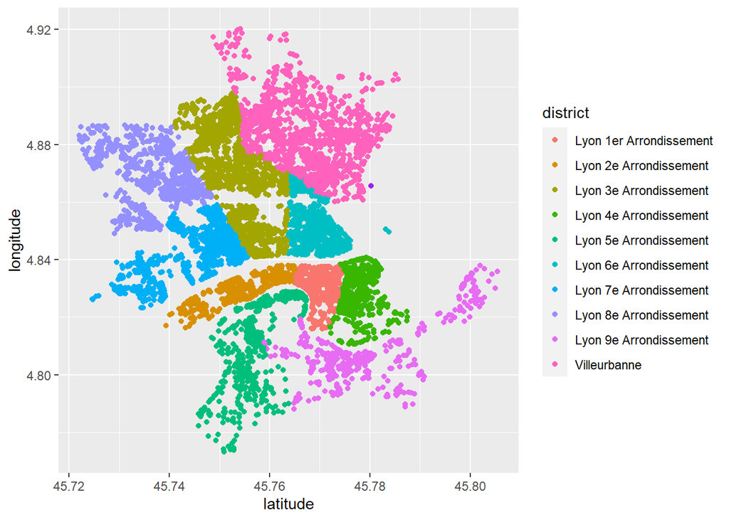

```r
a$district = as.factor(a$district)
ggplot(data = a)+geom_point(mapping = aes(x=latitude,y=longitude, color=district)) + geom_point(mapping = aes(45.780234113880425 , 4.865561717882041) , color="purple")
```

the university is located beside district “Villeurbanne”. again, lets see price of land in districts :

```r
ggplot(df2, aes(x=year, y=price, group=district)) +
  geom_line(aes(color=district))+
  geom_point(aes(color=district))
```

[output not shown]

so our search area for the house is just “Villeurbanne”.

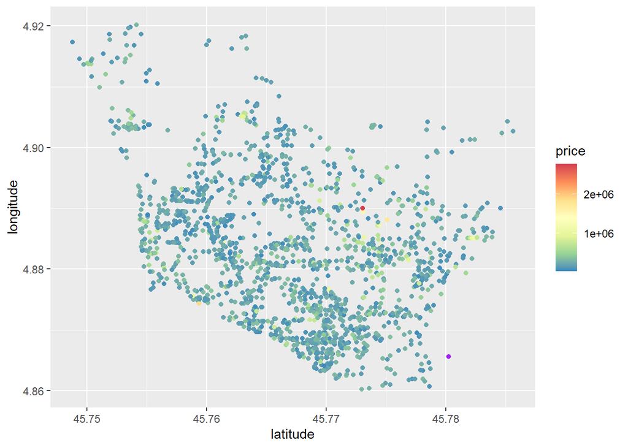

```r
vill = a[a$district=="Villeurbanne" ,]

ggplot()+geom_point(mapping = aes(x=vill$latitude,y=vill$longitude , color = vill$price) )+scale_color_distiller(name="price" ,palette = 'Spectral') + geom_point(mapping = aes(45.780234113880425 , 4.865561717882041) , color="purple") + xlab("latitude") + ylab("longitude")
```

nice! it seems some cheap houses are located near the university. let’s consider train stations in this area(red points) :

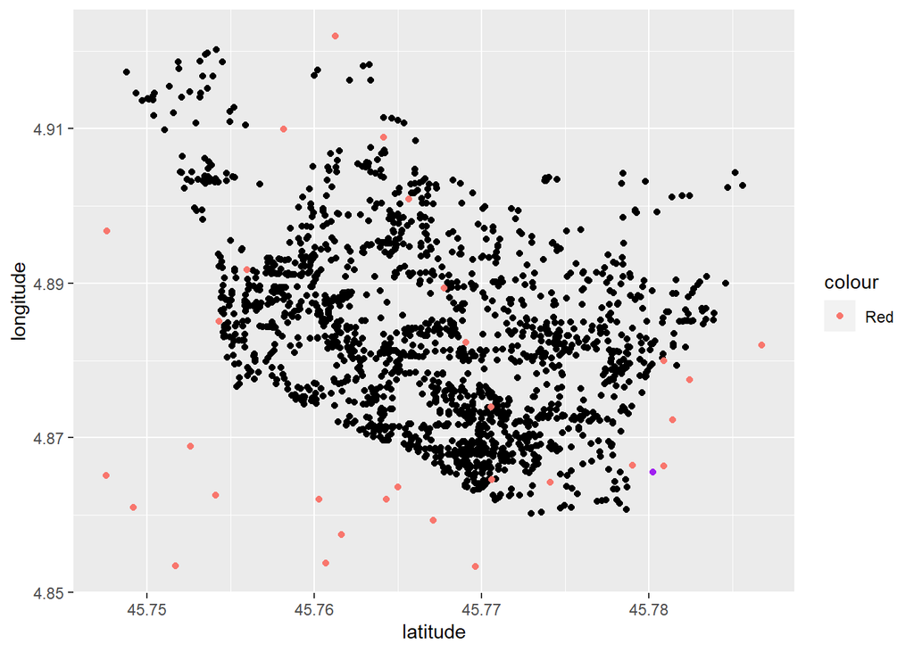

```r
AAB = stations
AAB$model = as.factor(AAB$model)
# colnames(AAB) = c("name" , "latitude" , "longitude" , "groups")


good = AAB[(45.79 > AAB$latitude)&(AAB$latitude > 45.746) & (4.85<AAB$longitude) &(AAB$longitude < 4.95) , ]
#
#
ggplot()+
  geom_point(mapping = aes(x=vill$latitude,y=vill$longitude))+
  geom_point(mapping = aes(45.780234113880425 , 4.865561717882041) , color="purple")+ geom_point(mapping = aes(good$latitude , good$longitude,color= "Red"))+xlab("latitude") + ylab("longitude")
```

Good! there some stations in this area. now I should be more specific for the features of a house i’m looking for. as a student, the most important factor is the price of the house. the second important factor is distance to university. the third important factor is distance to a station.

so i will define a cost function. with this cost function, I will test all houses in this area and then, i will select a house which has minimum cost for me.

first let’s calculate the distance of each house from university :

```r
  lat1 = a$latitude
  lat2 = 45.780234113880425
  lat1 = lat1 / ((180/pi))
  lat2 = lat2 / ((180/pi))

  lon1 = a$longitude
  lon2 = 4.865561717882041

  lon1 = lon1 / ((180/pi))
  lon2 = lon2 / ((180/pi))

  d = 3963.0 * acos((sin(lat1) * sin(lat2)) + cos(lat1) * cos(lat2) * cos(lon2-lon1))
  d = 1609.344 * d

  a$uni_distance = d

  vill = a[a$district=="Villeurbanne" ,]
  vill$station_distance = vill$station_distance*1000
  vill$price = vill$price / 100
```

we scale price and distances. now they are in the same order.

now let’s define our cost :

```r
c1 = 3
c2 = 2
c3 = 1

vill$cost = c1*vill$price + c2*vill$uni_distance + c3*vill$station_distance
vill = vill[order(vill$cost),]
```

now if we plot the best case :

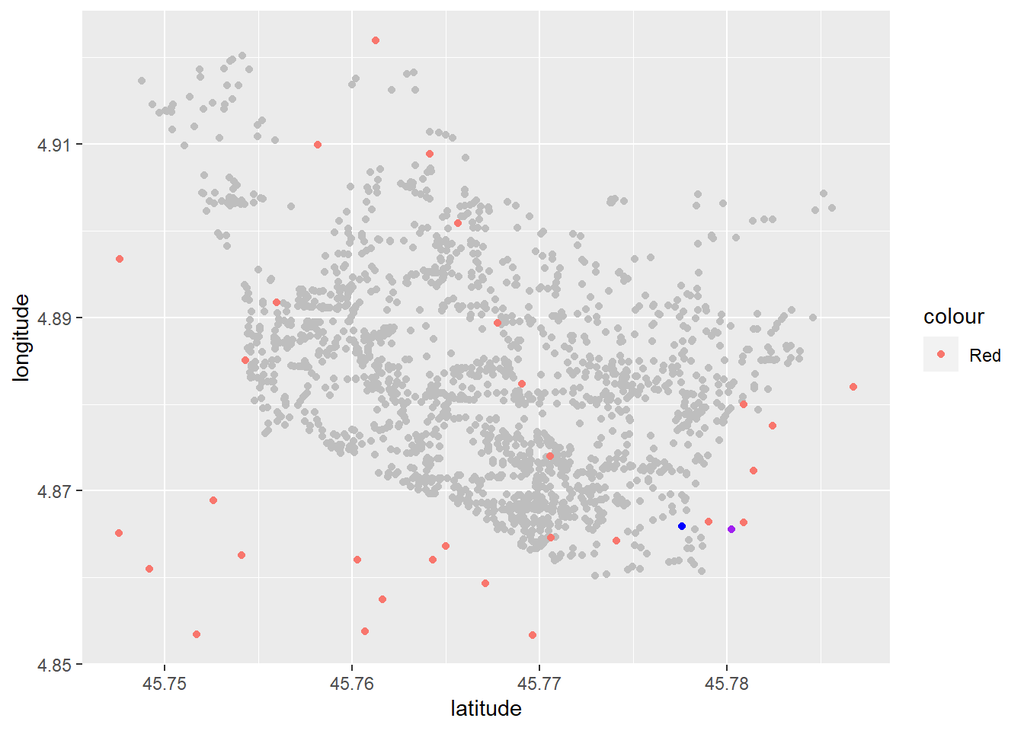

```r
ggplot()+
  geom_point(mapping = aes(x=vill$latitude,y=vill$longitude) , color="grey")+
  geom_point(mapping = aes(45.780234113880425 , 4.865561717882041) , color="purple")+ geom_point(mapping = aes(good$latitude , good$longitude,color= "Red"))+geom_point(mapping = aes(vill$latitude[1] , vill$longitude[1]) , color="blue")+xlab("latitude") + ylab("longitude")
```

OH YES! we found it.(we name this house as Beta House!) but let’s have a look at other houses.(maybe they have higher costs, but they have other good feature which can seduce us to buy them!)

```r
vill2 = vill[1:30 , ]
vill2$price = vill2$price * 100
head(vill2 , 'all')
```

|  | date_transaction | type_purchase | type_property | rooms_count | surface_housing | surface_terrain | parkings_count | price | address | district | latitude | longitude | date_construction | year | month | day | cons_year | cons_month | cons_day | station_distance | area_price_ratio | uni_distance | cost |
| --- | --- | --- | --- | --- | --- | --- | --- | --- | --- | --- | --- | --- | --- | --- | --- | --- | --- | --- | --- | --- | --- | --- | --- |
| 3778 | 19/10/29 | ancien | appartement | 2 | 30 | 0 | 1 | 31500 | 14 AV CONDORCET | Villeurbanne | 45.77760 | 4.865874 | 03/06/11 11:38 | 2019 | 10 | 29 | 2003 | 6 | 11 | 165.9196 | 1050.000 | 294.2147 | 1699.349 |
| 3776 | 18/04/20 | ancien | appartement | 1 | 34 | 0 | 0 | 36000 | 19 RUE DU TONKIN | Villeurbanne | 45.77760 | 4.865874 | 03/06/11 11:38 | 2018 | 04 | 20 | 2003 | 6 | 11 | 165.9196 | 1058.824 | 294.2147 | 1834.349 |
| 3430 | 16/09/09 | ancien | appartement | 2 | 37 | 0 | 0 | 45000 | 2 RUE MARTERET | Villeurbanne | 45.77784 | 4.872060 | 03/06/11 11:38 | 2016 | 09 | 09 | 2003 | 6 | 11 | 401.9135 | 1216.216 | 570.7572 | 2893.428 |
| 3407 | 16/09/26 | ancien | appartement | 1 | 21 | 0 | 0 | 64000 | 20 RUE MARGUERITE | Villeurbanne | 45.77778 | 4.868914 | 03/06/11 11:38 | 2016 | 09 | 26 | 2003 | 6 | 11 | 236.7944 | 3047.619 | 377.2201 | 2911.235 |
| 3411 | 17/03/21 | ancien | appartement | 1 | 21 | 0 | 0 | 61000 | 23 RUE DE BRUXELLES | Villeurbanne | 45.77759 | 4.869549 | 03/06/11 11:38 | 2017 | 03 | 21 | 2003 | 6 | 11 | 289.0829 | 2904.762 | 426.7562 | 2972.595 |
| 3406 | 16/09/13 | ancien | appartement | 1 | 25 | 0 | 0 | 68000 | 20 RUE MARGUERITE | Villeurbanne | 45.77778 | 4.868914 | 03/06/11 11:38 | 2016 | 09 | 13 | 2003 | 6 | 11 | 236.7944 | 2720.000 | 377.2201 | 3031.235 |
| 3413 | 18/01/16 | ancien | appartement | 1 | 21 | 0 | 0 | 63500 | 23 RUE DE BRUXELLES | Villeurbanne | 45.77759 | 4.869549 | 03/06/11 11:38 | 2018 | 01 | 16 | 2003 | 6 | 11 | 289.0829 | 3023.810 | 426.7562 | 3047.595 |
| 3414 | 18/10/19 | ancien | appartement | 1 | 21 | 0 | 0 | 64500 | 23 RUE DE BRUXELLES | Villeurbanne | 45.77759 | 4.869549 | 03/06/11 11:38 | 2018 | 10 | 19 | 2003 | 6 | 11 | 289.0829 | 3071.429 | 426.7562 | 3077.595 |
| 3417 | 20/03/27 | ancien | appartement | 1 | 21 | 0 | 0 | 65280 | 23 RUE DE BRUXELLES | Villeurbanne | 45.77759 | 4.869549 | 03/06/11 11:38 | 2020 | 03 | 27 | 2003 | 6 | 11 | 289.0829 | 3108.571 | 426.7562 | 3100.995 |
| 3408 | 16/10/27 | ancien | appartement | 1 | 25 | 0 | 0 | 72000 | 20 RUE MARGUERITE | Villeurbanne | 45.77778 | 4.868914 | 03/06/11 11:38 | 2016 | 10 | 27 | 2003 | 6 | 11 | 236.7944 | 2880.000 | 377.2201 | 3151.235 |
| 3507 | 18/12/27 | ancien | appartement | 1 | 32 | 0 | 1 | 63000 | 28 RUE BONNET | Villeurbanne | 45.77701 | 4.869565 | 03/06/11 11:38 | 2018 | 12 | 27 | 2003 | 6 | 11 | 330.6657 | 1968.750 | 474.8397 | 3170.345 |
| 3412 | 17/08/24 | ancien | appartement | 1 | 21 | 0 | 0 | 68000 | 23 RUE DE BRUXELLES | Villeurbanne | 45.77759 | 4.869549 | 03/06/11 11:38 | 2017 | 08 | 24 | 2003 | 6 | 11 | 289.0829 | 3238.095 | 426.7562 | 3182.595 |
| 3416 | 19/10/28 | ancien | appartement | 1 | 21 | 0 | 0 | 69000 | 23 RUE DE BRUXELLES | Villeurbanne | 45.77759 | 4.869549 | 03/06/11 11:38 | 2019 | 10 | 28 | 2003 | 6 | 11 | 289.0829 | 3285.714 | 426.7562 | 3212.595 |
| 3687 | 17/05/30 | ancien | appartement | 1 | 31 | 0 | 1 | 77500 | 1 ALL ATHENA | Villeurbanne | 45.77788 | 4.863394 | 03/06/11 11:38 | 2017 | 05 | 30 | 2003 | 6 | 11 | 269.6853 | 2500.000 | 311.0558 | 3216.797 |
| 3409 | 18/09/28 | ancien | appartement | 1 | 25 | 0 | 0 | 75000 | 20 RUE MARGUERITE | Villeurbanne | 45.77778 | 4.868914 | 03/06/11 11:38 | 2018 | 09 | 28 | 2003 | 6 | 11 | 236.7944 | 3000.000 | 377.2201 | 3241.235 |
| 3686 | 17/05/23 | ancien | appartement | 1 | 31 | 0 | 1 | 80000 | 1 ALL ATHENA | Villeurbanne | 45.77788 | 4.863394 | 03/06/11 11:38 | 2017 | 05 | 23 | 2003 | 6 | 11 | 269.6853 | 2580.645 | 311.0558 | 3291.797 |
| 3714 | 17/10/05 | ancien | appartement | 1 | 31 | 0 | 0 | 82000 | 9 AV ROBERTO ROSSELLINI | Villeurbanne | 45.77809 | 4.863317 | 03/06/11 11:38 | 2017 | 10 | 05 | 2003 | 6 | 11 | 264.8727 | 2645.161 | 295.1599 | 3315.193 |
| 3722 | 18/12/20 | ancien | appartement | 1 | 31 | 0 | 0 | 82700 | 9 AV ROBERTO ROSSELLINI | Villeurbanne | 45.77809 | 4.863317 | 03/06/11 11:38 | 2018 | 12 | 20 | 2003 | 6 | 11 | 264.8727 | 2667.742 | 295.1599 | 3336.193 |
| 3723 | 18/12/20 | ancien | appartement | 1 | 31 | 0 | 0 | 83000 | 9 AV ROBERTO ROSSELLINI | Villeurbanne | 45.77809 | 4.863317 | 03/06/11 11:38 | 2018 | 12 | 20 | 2003 | 6 | 11 | 264.8727 | 2677.419 | 295.1599 | 3345.193 |
| 3555 | 16/07/01 | ancien | appartement | 1 | 25 | 0 | 1 | 62000 | 17 AV ROGER SALENGRO | Villeurbanne | 45.77535 | 4.868801 | 15/12/02 11:38 | 2016 | 07 | 01 | 2015 | 12 | 02 | 379.6220 | 2480.000 | 598.9161 | 3437.454 |
| 3716 | 17/12/21 | ancien | appartement | 1 | 31 | 0 | 0 | 87500 | 9 AV ROBERTO ROSSELLINI | Villeurbanne | 45.77809 | 4.863317 | 03/06/11 11:38 | 2017 | 12 | 21 | 2003 | 6 | 11 | 264.8727 | 2822.581 | 295.1599 | 3480.193 |
| 3696 | 18/07/20 | ancien | appartement | 1 | 31 | 0 | 1 | 87200 | 1 ALL ATHENA | Villeurbanne | 45.77788 | 4.863394 | 03/06/11 11:38 | 2018 | 07 | 20 | 2003 | 6 | 11 | 269.6853 | 2812.903 | 311.0558 | 3507.797 |
| 3162 | 18/04/30 | ancien | appartement | 1 | 21 | 0 | 1 | 45000 | 37 RUE DESCARTES | Villeurbanne | 45.77397 | 4.872588 | 03/06/11 11:38 | 2018 | 04 | 30 | 2003 | 6 | 11 | 391.9836 | 2142.857 | 885.3951 | 3512.774 |
| 3751 | 19/10/24 | ancien | appartement | 1 | 31 | 0 | 1 | 95000 | 40 BD DU ONZE NOVEMBRE 1918 | Villeurbanne | 45.77871 | 4.863584 | 03/06/11 11:38 | 2019 | 10 | 24 | 2003 | 6 | 11 | 225.5178 | 3064.516 | 229.0627 | 3533.643 |
| 3512 | 17/01/11 | ancien | appartement | 1 | 28 | 0 | 1 | 74000 | 59 AV GALLINE | Villeurbanne | 45.77654 | 4.869215 | 03/06/11 11:38 | 2017 | 01 | 11 | 2003 | 6 | 11 | 351.2838 | 2642.857 | 499.8066 | 3570.897 |
| 3871 | 16/12/01 | ancien | appartement | 4 | 75 | 0 | 0 | 104643 | 4 RUE DU TONKIN | Villeurbanne | 45.77861 | 4.864574 | 18/05/23 11:38 | 2016 | 12 | 01 | 2018 | 5 | 23 | 153.1792 | 1395.240 | 196.3762 | 3685.222 |
| 3725 | 19/06/17 | ancien | appartement | 1 | 31 | 0 | 0 | 94400 | 9 AV ROBERTO ROSSELLINI | Villeurbanne | 45.77809 | 4.863317 | 03/06/11 11:38 | 2019 | 06 | 17 | 2003 | 6 | 11 | 264.8727 | 3045.161 | 295.1599 | 3687.193 |
| 2908 | 19/03/29 | ancien | appartement | 1 | 22 | 0 | 0 | 50000 | 14 RUE JUBIN | Villeurbanne | 45.77188 | 4.867919 | 03/06/11 11:38 | 2019 | 03 | 29 | 2003 | 6 | 11 | 294.2379 | 2272.727 | 947.4412 | 3689.120 |
| 3522 | 16/07/21 | ancien | appartement | 1 | 29 | 0 | 1 | 90000 | 6 RUE DE BRUXELLES | Villeurbanne | 45.77711 | 4.867586 | 03/06/11 11:38 | 2016 | 07 | 21 | 2003 | 6 | 11 | 231.9413 | 3103.448 | 381.8215 | 3695.584 |
| 87 | 16/08/25 | ancien | appartement | 1 | 30 | 0 | 0 | 36000 | 139 AV ROGER SALENGRO | Villeurbanne | 45.77958 | 4.881289 | 03/06/11 11:38 | 2016 | 08 | 25 | 2003 | 6 | 11 | 181.0342 | 1200.000 | 1223.0814 | 3707.197 |

OK. this is the list of 30 house with least value of cost function. among all this houses, our house has the minimum price. but let’s look at two other important features : distance to university and distance to nearest station.

if we look carefully, we noticed that there is only 1 house with better location versus Beta House . but, the price of this house is almost 3 times greater than Beta House. and as we mentioned in the begining, price of the house is the most important factor.

so, Beta house is the optimal chioce for me.

```r
vill2[1,]
```

|  | date_transaction | type_purchase | type_property | rooms_count | surface_housing | surface_terrain | parkings_count | price | address | district | latitude | longitude | date_construction | year | month | day | cons_year | cons_month | cons_day | station_distance | area_price_ratio | uni_distance | cost |
| --- | --- | --- | --- | --- | --- | --- | --- | --- | --- | --- | --- | --- | --- | --- | --- | --- | --- | --- | --- | --- | --- | --- | --- |
| 3778 | 19/10/29 | ancien | appartement | 2 | 30 | 0 | 1 | 31500 | 14 AV CONDORCET | Villeurbanne | 45.7776 | 4.865874 | 03/06/11 11:38 | 2019 | 10 | 29 | 2003 | 6 | 11 | 165.9196 | 1050 | 294.2147 | 1699.349 |

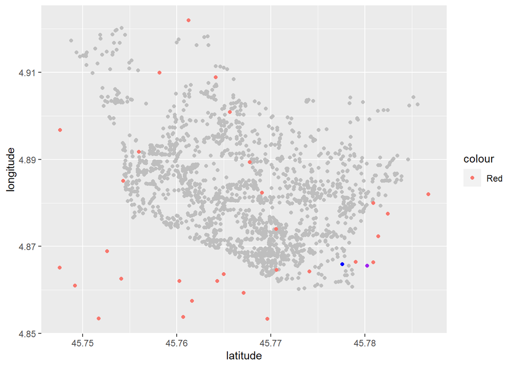

gray dots are houses in Villeurbanne, red dots are stations in this area, blue point is “Beta House” and purple dot is the university.

but this house is sold before. what we can do is to search in the area near this house to find another optimal house to buy.

THE END!